# PCIT-CoS-Waitlist RCT Paper 1: PSI

Nancy Briggs

31 May 2022

### PSI

#### Descriptives

| group | time | n | mean | sd | median | min | max |
| --- | --- | --- | --- | --- | --- | --- | --- |
| 1 | 1 | 27 | 83.307 | 7.878 | 83.50 | 64.5 | 97.8 |
| 1 | 2 | 21 | 94.214 | 5.014 | 95.50 | 85.5 | 101.0 |
| 1 | 3 | 16 | 90.656 | 5.101 | 91.00 | 80.5 | 98.5 |
| 2 | 1 | 27 | 80.259 | 12.087 | 81.50 | 51.5 | 101.5 |
| 2 | 2 | 12 | 85.792 | 7.668 | 87.50 | 76.5 | 96.0 |
| 2 | 3 | 4 | 82.375 | 7.696 | 82.75 | 73.0 | 91.0 |
| 3 | 1 | 26 | 80.519 | 9.390 | 82.25 | 55.0 | 93.5 |
| 3 | 2 | 19 | 81.553 | 9.720 | 83.00 | 63.5 | 95.0 |
| 3 | 3 | 1 | 81.000 | NA | 81.00 | 81.0 | 81.0 |

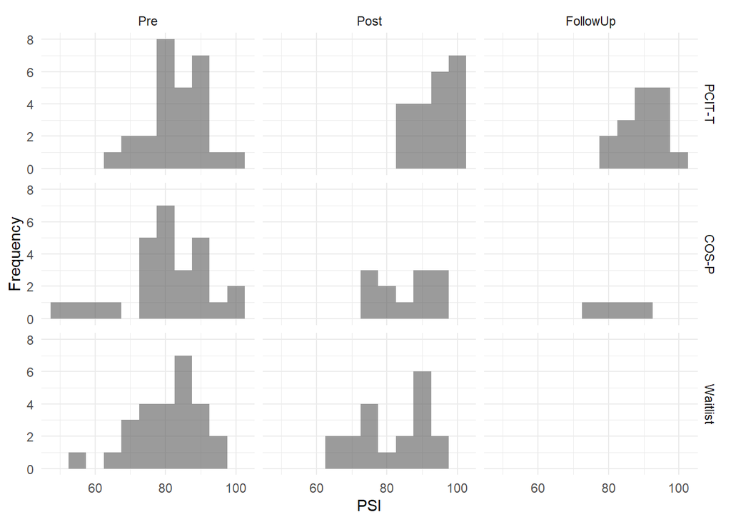

#### Model & Results

A linear mixed model with random effect for individual and fixed effects of group, time and the interaction was run. Estimated marginal means were obtained, and contrasts specified to test Hypothesis 1 and Hypothesis 2.

```
## fixed-effect model matrix is rank deficient so dropping 1 column / coefficient
```

```
## refitting model(s) with ML (instead of REML)
```

|  | Effect | npar | AIC | BIC | logLik | deviance | Chisq | Df | Pr(>Chisq) |
| --- | --- | --- | --- | --- | --- | --- | --- | --- | --- |
| result0 | Intercept | 3 | 1120.667 | 1129.738 | -557.333 | 1114.667 | NA | NA | NA |
| result1 | Group | 5 | 1110.318 | 1125.437 | -550.159 | 1100.318 | 14.349 | 2 | 0.001 |
| result2 | Time | 7 | 1096.970 | 1118.137 | -541.485 | 1082.970 | 17.348 | 2 | 0.000 |
| result3 | Group*Time | 10 | 1089.237 | 1119.476 | -534.618 | 1069.237 | 13.733 | 3 | 0.003 |

```r
summary(result3)
```

```
## Linear mixed model fit by REML. t-tests use Satterthwaite's method [
## lmerModLmerTest]
## Formula: outcome ~ group * time + (1 | id)
##    Data: dat
##
## REML criterion at convergence: 1043.8
##
## Scaled residuals:
##      Min       1Q   Median       3Q      Max
## -2.19522 -0.49692  0.06785  0.52945  1.61182
##
## Random effects:
##  Groups   Name        Variance Std.Dev.
##  id       (Intercept) 43.62    6.604
##  Residual             38.63    6.216
## Number of obs: 152, groups:  id, 85
##
## Fixed effects:
##              Estimate Std. Error      df t value Pr(>|t|)
## (Intercept)    83.379      1.726 110.727  48.308  < 2e-16 ***
## group2         -2.830      2.442 110.620  -1.159  0.24904
## group3         -3.224      2.472 109.053  -1.304  0.19493
## time2          10.545      1.905  60.510   5.535 7.08e-07 ***
## time3           6.690      2.088  60.730   3.205  0.00216 **
## group2:time2   -6.710      3.094  70.273  -2.169  0.03348 *
## group3:time2   -9.350      2.746  60.770  -3.405  0.00118 **
## group2:time3   -9.625      4.424  73.643  -2.176  0.03279 *
## ---
## Signif. codes:  0 '***' 0.001 '**' 0.01 '*' 0.05 '.' 0.1 ' ' 1
##
## Correlation of Fixed Effects:
##             (Intr) group2 group3 time2  time3  grp2:2 grp3:2
## group2      -0.707
## group3      -0.698  0.494
## time2       -0.457  0.323  0.319
## time3       -0.409  0.289  0.286  0.431
## group2:tim2  0.281 -0.408 -0.196 -0.616 -0.265
## group3:tim2  0.317 -0.224 -0.447 -0.694 -0.299  0.427
## group2:tim3  0.193 -0.288 -0.135 -0.203 -0.472  0.303  0.141
## fit warnings:
## fixed-effect model matrix is rank deficient so dropping 1 column / coefficient
```

#### Estimated Means & Change

Estimated means for each Treatment and Time are presented. In addition, within-group change between time points is presented with 95% CIs.

##### Group mean difference at each timepoint

Effect sizes all calculated by the pooled T1 SD of the outcome. Adjusted p-value from Bonferroni correction.

Group Differences at Each Time Point

[output not shown]

* Effect size scaled by pooled T1 SD  
† ES 95% Bootstrapped Percentile CI limits  
‡ If you want a positive ES (and it is calculated as negative), be sure to switch the signs and positions of the lower and upper CIs.

##### Change within each group

Within-Group Change and Effect Sizes

[output not shown]

* Effect size scaled by pooled T1 SD  
† ES 95% Bootstrapped Percentile CI limits  
‡ If you want a positive ES (and it is calculated as negative), be sure to switch the signs and positions of the lower and upper CIs.

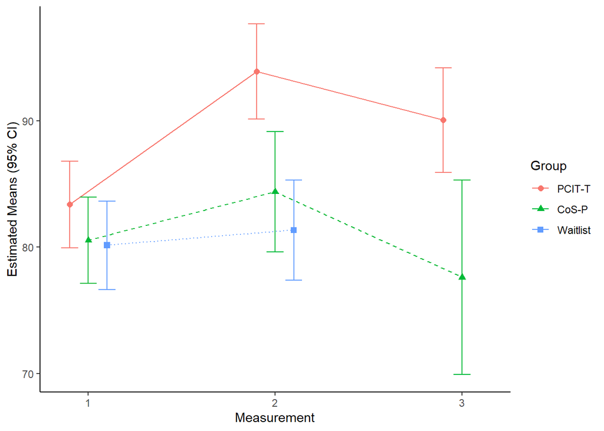

#### Hypothesis 1

We hypothesize that from baseline (‘T1’) to post-treatment/waitlist (‘T2’) there will be a gradient effect, whereby parent-child dyads who receive PCIT-T will show the greatest gains and parent-child dyads who receive no treatment will show the least gains. For the outcome, then, the null hypothesis is:

$H_0: \text {mean change}(\text{PCIT-T}) = \text {mean change}(\text{CoS-P}) = \text {mean change}(\text{Waitlist})$ $H_A: \text {mean change}(\text{PCIT-T}) > \text {mean change}(\text{CoS-P})$ $\&$ $\text {mean change}(\text{CoS-P}) > \text {mean change}(\text{Waitlist})$

For this, we test two tests, and then look at the magnitude of change within each group.

First, testing the two comparisons:

```
## group = 1:
##  contrast estimate   SE   df t.ratio p.value
##  1 - 2      -10.55 1.91 73.8  -5.518  <.0001
##  1 - 3       -6.69 2.10 74.0  -3.193  0.0058
##  2 - 3        3.85 2.14 68.6   1.801  0.1767
##
## group = 2:
##  contrast estimate   SE   df t.ratio p.value
##  1 - 2       -3.83 2.46 90.0  -1.562  0.2674
##  1 - 3        2.93 3.93 90.8   0.746  0.7367
##  2 - 3        6.77 4.06 81.5   1.667  0.2240
##
## group = 3:
##  contrast estimate   SE   df t.ratio p.value
##  1 - 2       -1.20 1.98 74.3  -0.603  0.8192
##  1 - 3      nonEst   NA   NA      NA      NA
##  2 - 3      nonEst   NA   NA      NA      NA
##
## Degrees-of-freedom method: kenward-roger
## P value adjustment: tukey method for comparing a family of 3 estimates
```

[output not shown]

For test of difference between G1 and G2 in change from T1-2:  
p= 0.03. We have evidence that there is a difference in the change over from Baseline to Post between the groups. The adjusted pvalue is 0.06.

p-values adjusted by Holm’s stepdown procedure.

| contrast | group | t1t2change | quality | p.value |
| --- | --- | --- | --- | --- |
| 1 - 2 | 1 | 10.545 | increase t1 to t2 | 0.000 |
| 1 - 2 | 2 | 3.835 | increase t1 to t2 | 0.267 |
| 1 - 2 | 3 | 1.195 | increase t1 to t2 | 0.819 |

Is the ordering of change satisfied?

Assuming an increase is better (positive change is improvement)

Greatest to least change from t1 to t2: change in PCITT > COS-P > Waitlist

Assuming an decrease is better (negative change is improvement)

Greatest to least change from t1 to t2: Order not satisfied

#### Hypothesis 2

##### Change from T2-T3

There will be a gradient of size of change from T2 to T3 such that the change in the PCIT-T group > the change in the CoS-P group. This isn’t really a gradient; it’s just 1 hypothesis.

First, the change in PCITT and COSP from time 2 to time 3:

```
## group = 1:
##  time emmean   SE  df lower.CL upper.CL
##  1      83.4 1.73 119     80.0     86.8
##  2      93.9 1.90 134     90.2     97.7
##  3      90.1 2.10 143     85.9     94.2
##
## group = 2:
##  time emmean   SE  df lower.CL upper.CL
##  1      80.5 1.73 119     77.1     84.0
##  2      84.4 2.41 144     79.6     89.2
##  3      77.6 3.89 117     69.9     85.3
##
## group = 3:
##  time emmean   SE  df lower.CL upper.CL
##  1      80.2 1.77 117     76.6     83.7
##  2      81.4 2.00 135     77.4     85.3
##  3    nonEst   NA  NA       NA       NA
##
## Degrees-of-freedom method: kenward-roger
## Confidence level used: 0.95
```

```
## group = 1:
##  contrast estimate   SE   df lower.CL upper.CL
##  1 - 2      -10.55 1.91 73.8   -15.12    -5.97
##  1 - 3       -6.69 2.10 74.0   -11.70    -1.68
##  2 - 3        3.85 2.14 68.6    -1.27     8.98
##
## group = 2:
##  contrast estimate   SE   df lower.CL upper.CL
##  1 - 2       -3.83 2.46 90.0    -9.69     2.02
##  1 - 3        2.93 3.93 90.8    -6.44    12.31
##  2 - 3        6.77 4.06 81.5    -2.92    16.46
##
## group = 3:
##  contrast estimate   SE   df lower.CL upper.CL
##  1 - 2       -1.20 1.98 74.3    -5.94     3.55
##  1 - 3      nonEst   NA   NA       NA       NA
##  2 - 3      nonEst   NA   NA       NA       NA
##
## Degrees-of-freedom method: kenward-roger
## Confidence level used: 0.95
## Conf-level adjustment: tukey method for comparing a family of 3 estimates
```

```r
## Specify contrast matrices
# Hyp1 is 1 df test
# could use alternative="less" ir alternative="greater" in glht
hyp2   <- matrix(c(0, 0,0, 0,0, -1,0,1 ),1)
hyp2F <- glht(result3, linfct = hyp2)
summary(hyp2F)
```

```
##
##   Simultaneous Tests for General Linear Hypotheses
##
## Fit: lmer(formula = outcome ~ group * time + (1 | id), data = dat)
##
## Linear Hypotheses:
##        Estimate Std. Error z value Pr(>|z|)
## 1 == 0   -2.915      4.565  -0.639    0.523
## (Adjusted p values reported -- single-step method)
```

```r
s<-summary(hyp2F, test = Ftest())
#also see this webpage for more on contrasts https://rcompanion.org/rcompanion/h_01.html



## Extract pvaue for evidence / no evidence
evidence = ifelse(s$test$pvalue<0.05, "evidence", "no evidence")
```

Change in G1 from T2 to T3: 3.855

Change in G2 from T2 to T3: 6.77

##### Change from T1-T3

```
##
##   General Linear Hypotheses
##
## Linear Hypotheses:
##        Estimate
## 1 == 0   -9.625
##
## Global Test:
##       F DF1 DF2  Pr(>F)
## 1 4.733   1 142 0.03124
```

Change in G1 from T1 to T3: -6.69

Change in G2 from T1 to T3: 2.935

p=0.0312. We have evidence that the change from T1 to T3 is different for G1 and G2

#### Residuals

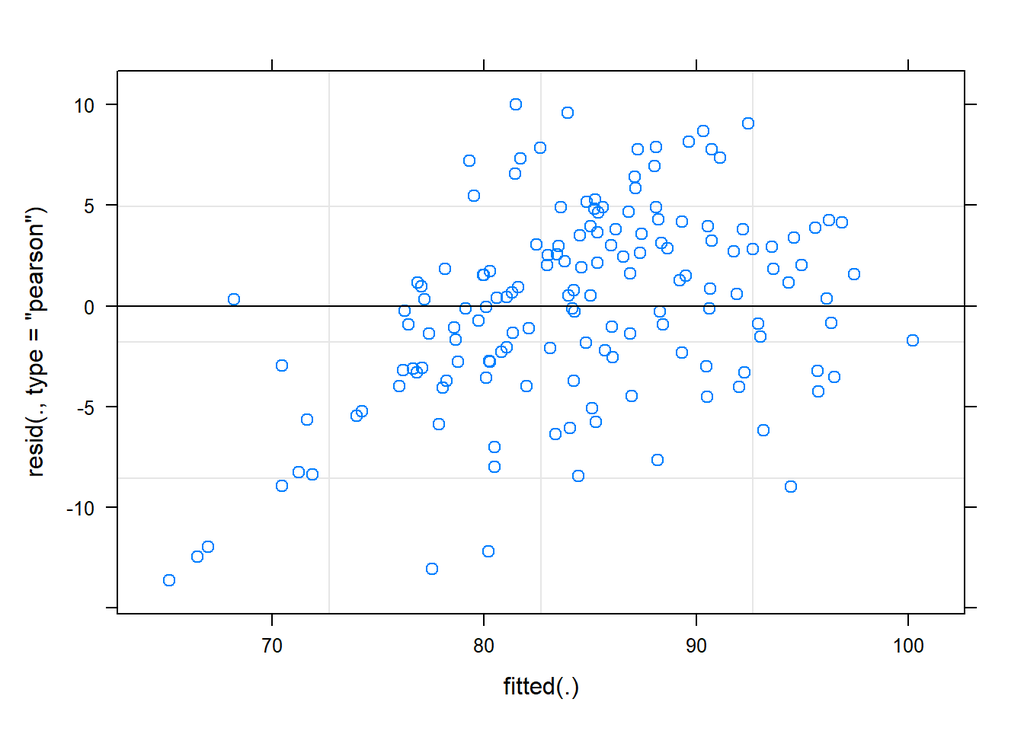

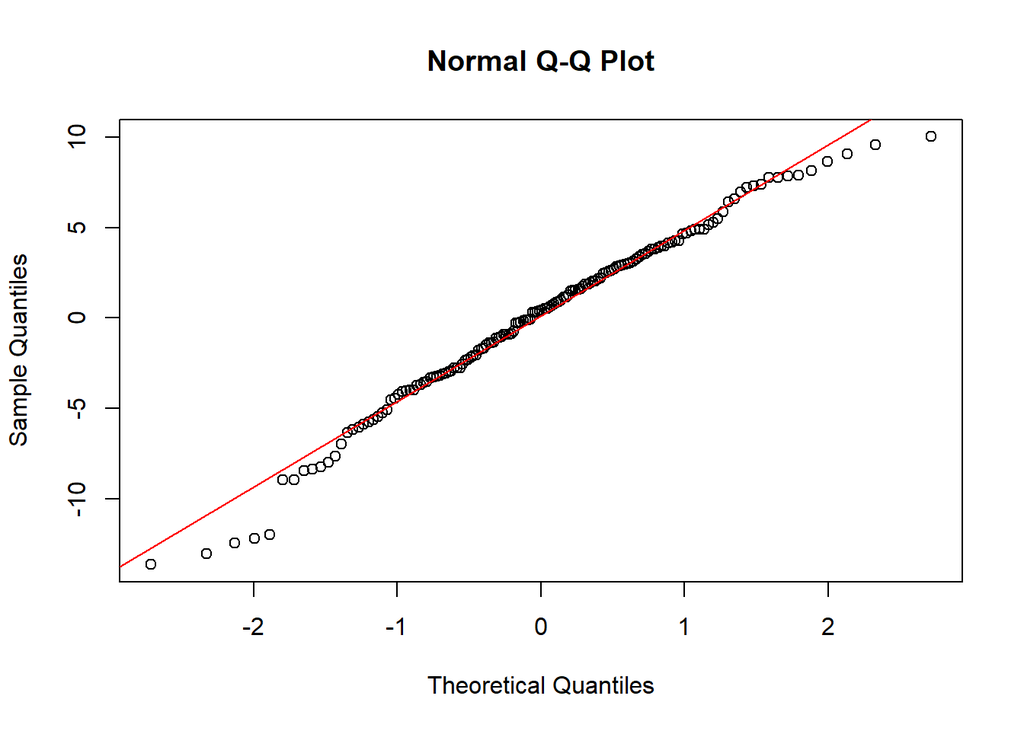

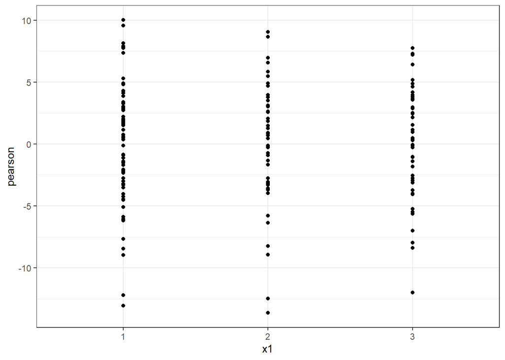

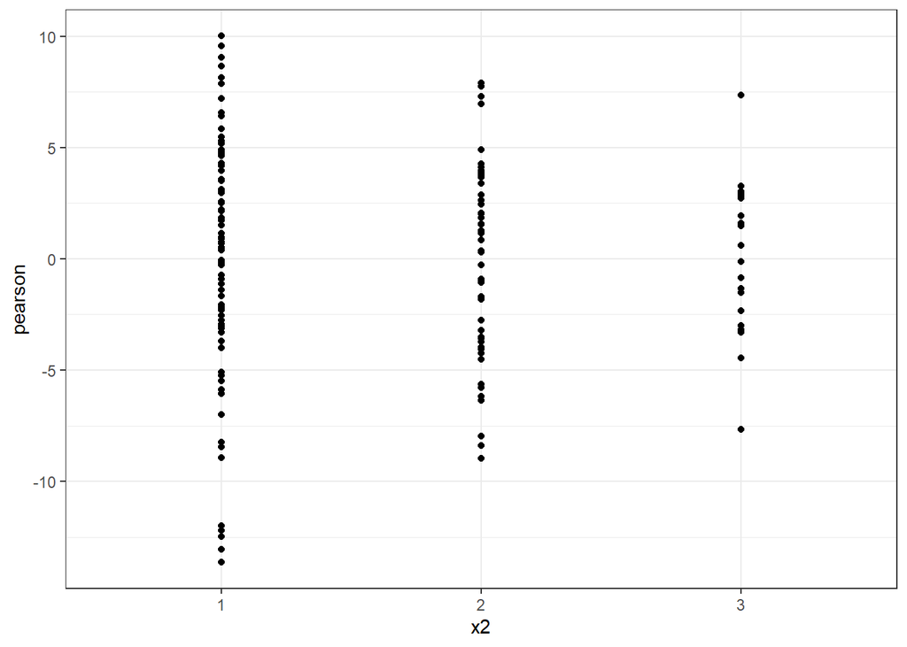

```r
rm(list = ls())
```